# Lesson 01 - Introduction to Machine Learning

### The following topics are discussed in this notebook:

- Overview of machine learning.
- Discussion supervised vs unsupervised learning.
- Examples of regression and classification tasks.
- Examples of clustering tasks.

### Additional Resources

- Chapter 01 of **Hands-On Machine Learning**.
- [Machine Learning for Humans, Part 1: Why Machine Learning Matters](https://medium.com/machine-learning-for-humans/why-machine-learning-matters-6164faf1df12)

## What is Machine Learning

Machine learning is a subfield of artificial intelligence. Its goal is to enable computers to learn on their own. A machine’s learning algorithm enables it to identify patterns in observed data, build models that explain the world, and predict things without having explicit pre-programmed rules and models.

### Applications of Machine Learning

Machine learning has applications in many fields. A (non-exaustive) list of applications includes spam detection, generating search results, image classification, voice recognition, programming autonomous vehicles, predicting credit scores, predicting housing costs, medical diagnoses, recommender systems, and handwriting recognition.

### Model Building

The goal of machine learning is to construct models that allow us to identify trends and make predictions. A machine learning algorithm "trains" on data that is provided to it, and then outputs a model that can be used to generalize beyond the training data.

## Types of Machine Learning Algorithms

There are three main categories of machine learning problems: **supervised learning**, **unsupervised learning**, and **reinforcement learning**.

## Supervised Learning

In a supervised learning task, the goal is to generate a model that can predict an output based on one or many input values.

- The output is typically called a **label**, **target value**, or **response variable**.
- The inputs are typically called **features** or **predictors**.

The algorithm "learns" the optimal model by studying a training set of data that consists of several **observations** (or **instances**, or **samples**), each of which contains values for both its features and its label.

Supervised learning tasks can be further classified into regression and classification problems.

- **Regression.** A regression task is one for which the target values are continuous, real numbers.
- **Classification.** A classification task is one for which the target values are discrete classes.

The following example introduces the iris data set, which is commonly used to illustrate ideas in data science. If we view the `species` column as the label, then this data set could be used to train a classifier.

```python
import pandas as pd
iris = pd.read_table(filepath_or_buffer='Datasets\iris.txt', sep='\t')
iris.head(n=10)
```

|  | Sepal.Length | Sepal.Width | Petal.Length | Petal.Width | Species |
| --- | --- | --- | --- | --- | --- |
| 0 | 5.5 | 4.2 | 1.4 | 0.2 | setosa |
| 1 | 5.6 | 3.0 | 4.5 | 1.5 | versicolor |
| 2 | 7.2 | 3.6 | 6.1 | 2.5 | virginica |
| 3 | 4.8 | 3.0 | 1.4 | 0.3 | setosa |
| 4 | 5.5 | 2.4 | 3.8 | 1.1 | versicolor |
| 5 | 5.8 | 2.7 | 3.9 | 1.2 | versicolor |
| 6 | 6.0 | 3.4 | 4.5 | 1.6 | versicolor |
| 7 | 7.7 | 3.0 | 6.1 | 2.3 | virginica |
| 8 | 6.2 | 2.9 | 4.3 | 1.3 | versicolor |
| 9 | 4.9 | 3.1 | 1.5 | 0.2 | setosa |

[figure not shown]

## Objective Functions

A supervised learning algorithm uses the data it is provided to learn the optimal model for the data it was provided. It determines which model is optimal by trying to either minimize or maximize an **objective function** that is used to score the model.

## Training a Regression Algorithm: Sum of Squared Errors

For regression tasks, a common objective function is the **sum of squared errors**, or **SSE**. Assume that our training set has $n$ observations, whose labels are denoted by $y_1, y_2, ..., y_n$. Assume that we create a regression model, and based on the features of the observations in our training set, the model predicts outputs of $\hat{y}_1, \hat{y}_2, ..., \hat{y}_n$. For each observation, we can define the error of the prediction to be $\hat{e}_i = \hat{y}_i - y_i$. Having calculated the errors for each of our training instances, we can then calculate the SSE as follows:

$\hspace{10 mm} \large SSE = \sum \hat{e}_i^2 $

The goal of the algorithm is the find the model that produces the lowest SSE. Consider the following example, which illustrates the linear regression algorithm.

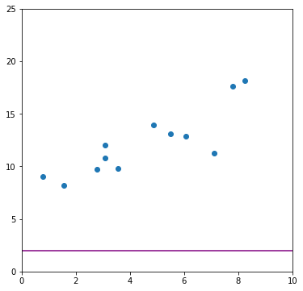

```
Sum of Squared Errors: 1357.20356444
```

```python
%run -i examples/example01.py
```

## Regression Algorithms

Several algorithms commonly used for regresion tasks are listed below.

- Linear Regression
- K-Nearest Neighbors
- Support Vector Machines
- Decision Trees
- Neural Networks

## Training a Classification Algorithm: Accuracy

A common objective function used for scoring a classification algorithm is **accuracy**. After using the training data to generate a classification model, we can then apply that model to each of the instances in the training data to generate class predictions for each instance. The accuracy of the model is simply the proportion of instances that have been correctly classified. The goal of the learning algorithm is to find the algorithm with the highest accuracy.

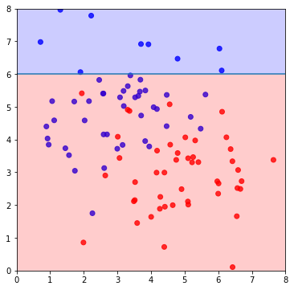

```
True Blue:  9
False Blue: 0
True Red:   50
False Red:  41

Accuracy: 0.59
```

```python
%run -i examples/example02.py
```

**Classification Algorithms**

Several algorithms commonly used for classification tasks are listed below.

- Logistic Regression
- K-Nearest Neighbors
- Support Vector Machines
- Decision Trees
- Naive Bayes
- Neural Networks

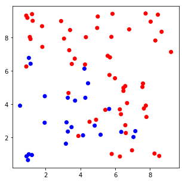

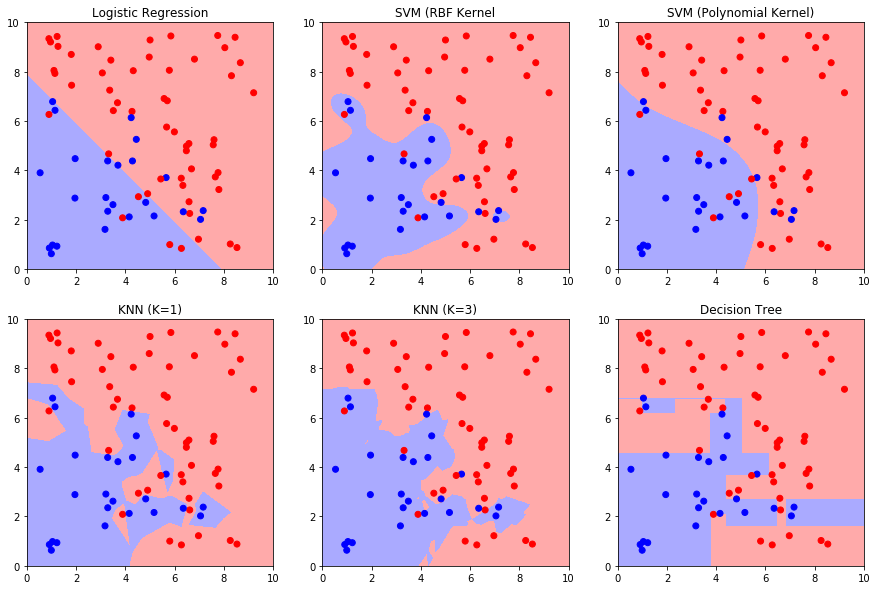

```python
%run -i examples/example03.py
```

## Unsupervised Learning

In unsupervised learning, we work with data sets in which features are provided, but no labels. Not only are the labels "missing", but we typically do not start an unsupervised learning tasks with a preconception of what the possible labels might be. The goal of unsupervised learning is to identify structure within the data that might not be readily perceptible to humans.

Two common unsupervised learning tasks are:

- Clustering
- Outlier Detection

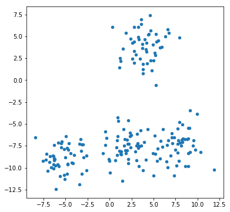

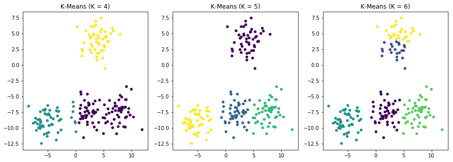

```python
%run -i examples/example04.py
```

## Reinforcement Learning

In reinforcement learning task, a notion of "success" is defined, and a method of score the level of success is provided. The algoirthm then collects a training set through trial-and-error. Which each new attempt, the algorithm recieves feedback regarding its performance, and then makes adjustments as needed.